# WaterML2 Part 3: Surface Hydrology Features (HY_Features)

David L. Blodgett  
10-2017

A conceptual feature model for surface hydrology.

For more info, visit the [SWG home page.](http://www.opengeospatial.org/projects/groups/hydrofeatswg)

Longer version of this [presentation here.](http://opengeospatial.github.io/HY_Features/HY_Features_primer/HY_Features_Primer.html#/)

Google: “HY_Features” and look for **Hydrologic Features SWG**

# **What is HY_Features?**

1

## HY_Features is a conceptual model describing hydrology features and their relationships

- **catchments, drainage networks, rivers, lakes and waterbodies.**
- **Focus is on surface water features and the networks they form.**

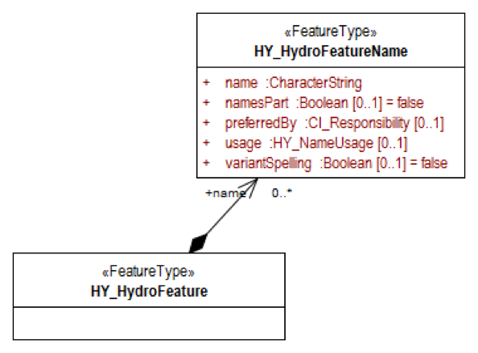

# **What is HY_Features for?**

## HY_Features provides a common concepts for hydrologic features.

2

# **What kinds of features are in HY_Features?**

### HY_Features includes:

- **hydrologic unit features**,
- the **junction features** that join them,
- and the **waterbody features** that drain them.

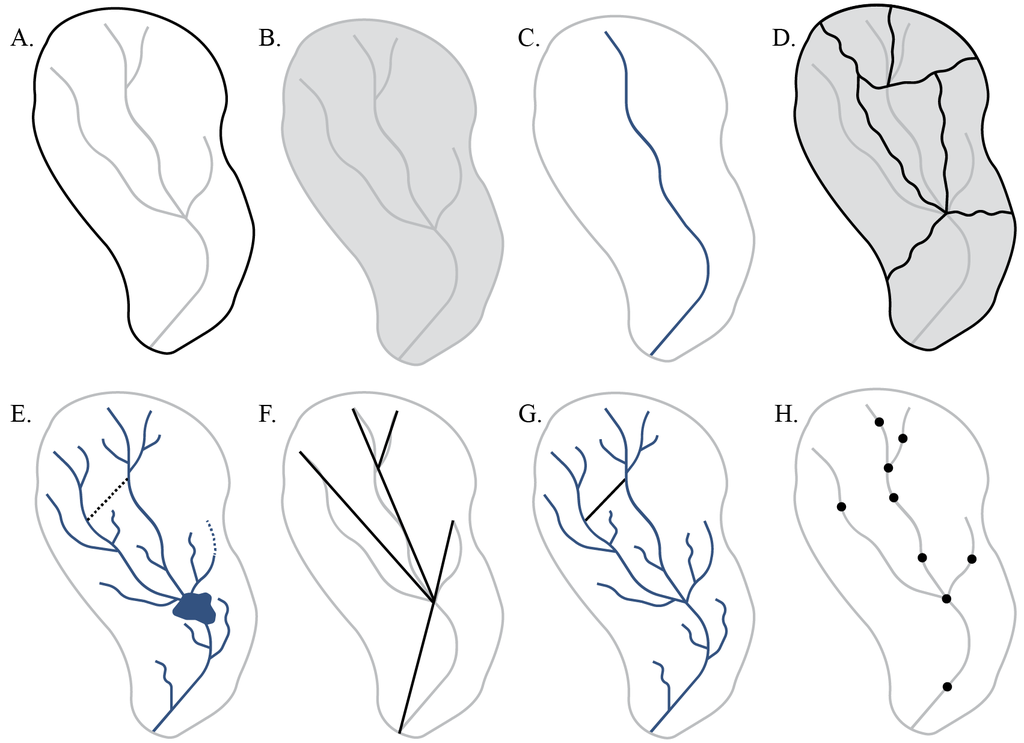

3

# **What is a catchment?**

## Catchment is a holistic abstract notion of a hydrologic unit (a feature type).

### It is a physiographic unit defined by a common outlet (and potentially an upstream inlet.)

4

# **What is a Hydro Nexus?**

## A place where two or more catchments interact

### Could be anywhere, typically confluences, or gages, etc.

[figure not shown]

5

6

## **Waterbody, Hydro Location, Catchment, and Nexus**

1. **waterbody**

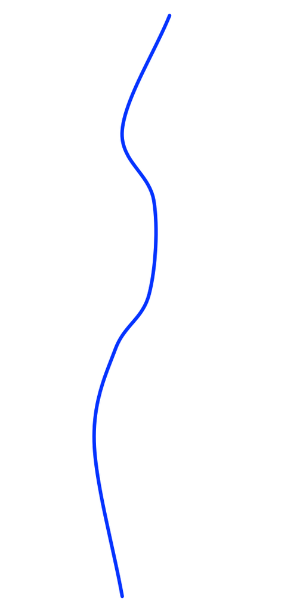

7

## **Waterbody, Hydro Location, Catchment, and Nexus**

1. **waterbody**
2. **hydrologic locations**

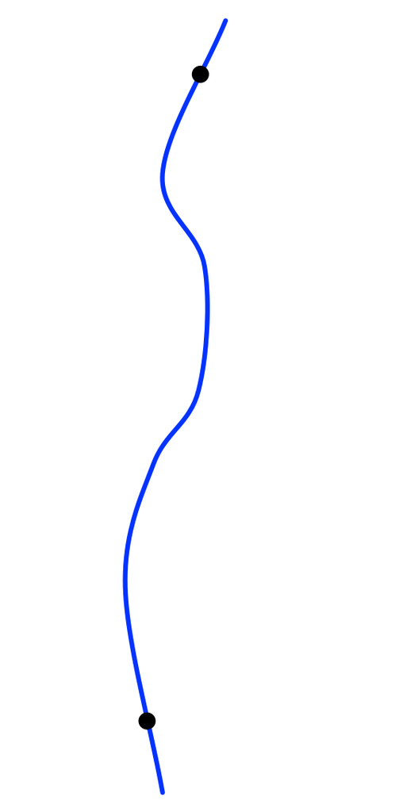

8

## **Waterbody, Hydro Location, Catchment, and Nexus**

1. **waterbody**
2. **hydrologic locations**
3. **divide**

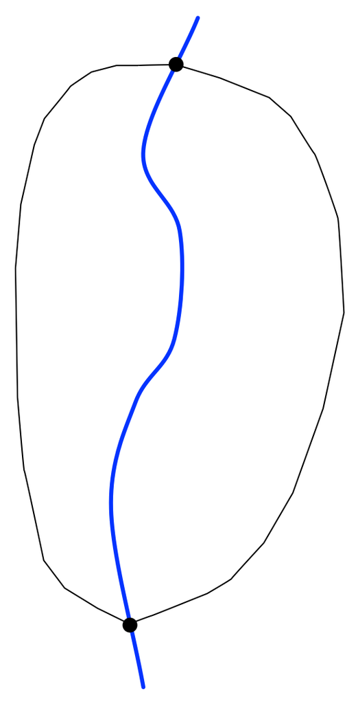

9

## **Waterbody, Hydro Location, Catchment, and Nexus**

1. **waterbody**
2. **hydrologic locations**
3. **divide** around **area**

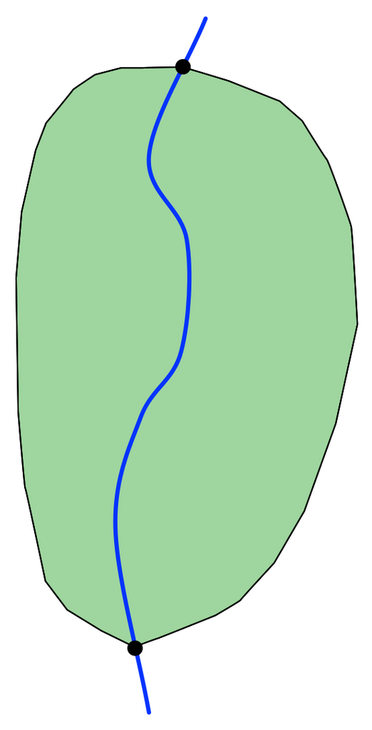

10

## **Waterbody, Hydro Location, Catchment, and Nexus**

1. **waterbody**
2. **hydrologic locations**
3. **divide** around **area**
4. Given ID: **catchment**

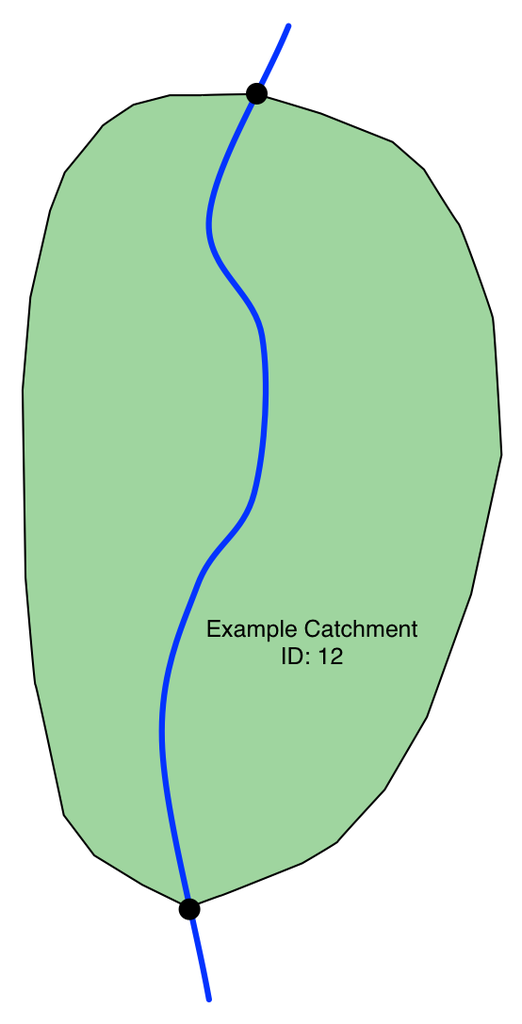

11

## **Waterbody, Hydro Location, Catchment, and Nexus**

1. **waterbody**
2. **hydrologic locations**
3. **divide** around **area**
4. Given ID: **catchment**.
5. Identified catchment has **hydrologic nexuses**

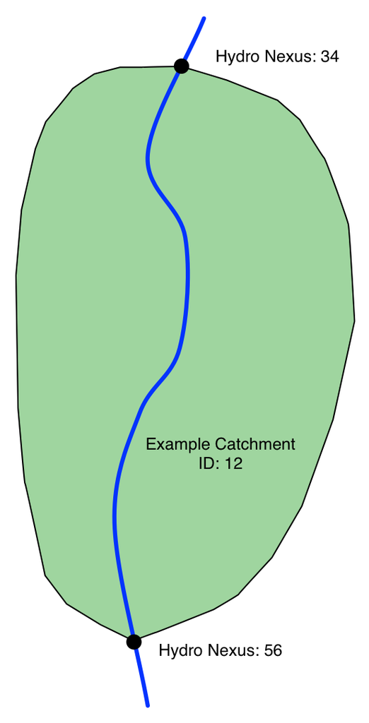

12

## **Waterbody, Hydro Location, Catchment, and Nexus**

Catchment *12* has inflow hydro nexus *34* and outflow hydro nexus *56*.

Catchment *12* is realized as a *divide*, *area* and *flowpath*.

Hydro nexuses *34*, and *56* are realized as hydro locations.

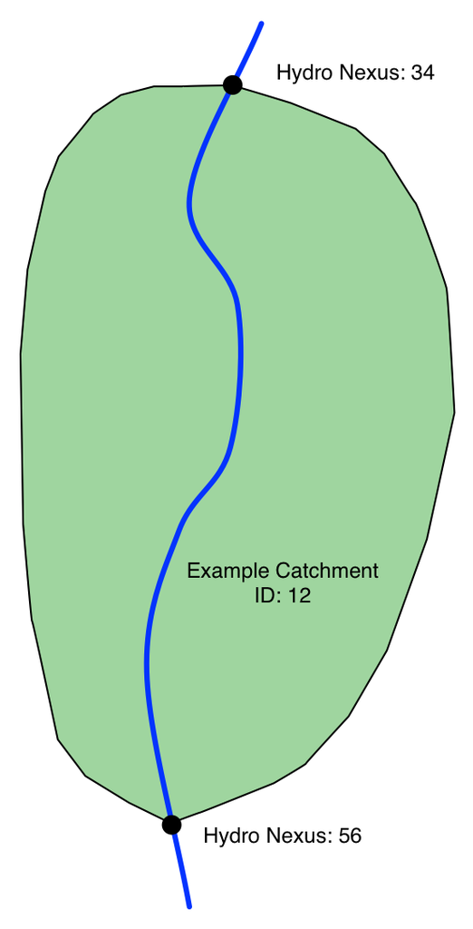

13

## **Waterbody, Hydro Location, Catchment, and Nexus**

### There might be multiple representations for each realization.

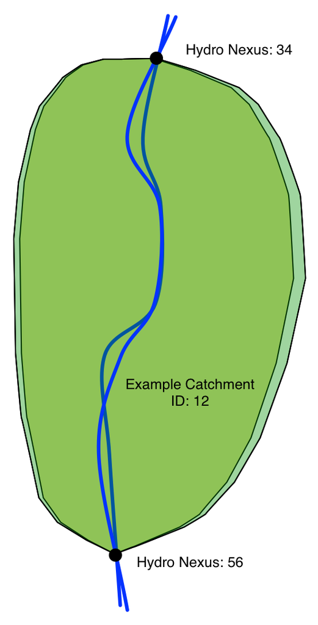

14

**Networks of Waterbodies and/or Channels**

Waterbody network - Blue

Channel network - Orange

Hydro nexus hydrologic locations - Black dots

Catchment Boundaries - Black Boundary

[figure not shown]

HY_Features goes much much deeper…

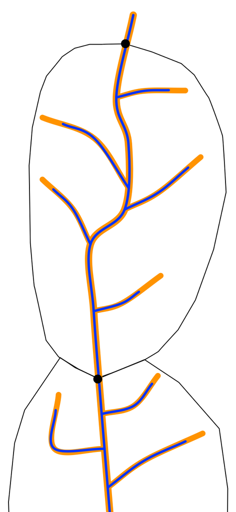